# Coursework Report

*N* removed NAs: 2

*N* removed typo: 1

*N* removed <18: 23

*N* total clean: 124

| Group | *N* | *M*<sub>age</sub> | *M*<sub>rating</sub> |
| --- | --- | --- | --- |
| Control | 65 | 21.08 | 5.46 |
| Experim | 59 | 21.29 | 6.12 |

**Main analysis results**

*t*(122) = -4.65, *p* < .001

[interactive chart not shown]

[figure not shown]

[interactive chart not shown]

# Coursework Report

Analysing Data, Spring 2020

# Methods

## Participants

Table * Descriptive statistic by years*

| *mean*<sub>years</sub> | *SD*<sub>years</sub> | *min*<sub>years</sub> | *max*<sub>years</sub> |
| --- | --- | --- | --- |
| 21.18 | 2.16 | 18 | 28 |

## Design

The conceptual hypothesis of this study was whether colour influences attractiveness. This conceptual hypothesis can be operationalised in order to make a operational hypothesis of whether viewing an image of a moderately attractive man framed in different colour frames would influence the mean rating of the man’s attractiveness. The study was operationalised in many ways. Firstly, the participants saw one of two pictures in a frame, and they were split into two conditions, the control condition where the frame was white and the experimental condition where the frame was red. The colour of the frame that the participants were shown was an example of an independent categorical variable. In order to measure, the perceived attractiveness of the male a 1 - 9 rating scale was used. This rating scale included three questions, item 1 being “how attractive do you think this person is?”, item 2 being “how pleasant is this person to look at?” and item 3 being “if I were to meet the person in this picture face to face i would think he is attractive?”. The answers gathered from the three questions were averaged to get a composite score. The attractiveness variable, is a continuous variable. This study will use the t-test to check the significance of the results in relation to the operationalised hypothesis.

# Results

The results from this study have shown that the participants who were in the experimental group and viewed the male in a red frame, rated his attractiveness higher than the participants in the control conditions where they viewed the male in a white frame. The mean attractiveness rating for the experimental condition was 6.12 and the mean attractiveness rating for the control condition was 5.46. in both conditions participants were asked three questions which were used to provide a mean attractiveness rating. The mean for the first question in the control condition was 5.55 whereas in the experimental condition it was 6.19. Next the mean for the second question for the control condition was 5.31 and for the experimental condition it was 5.97. And finally the third question the mean score for it in the control condition was 5.52 and for the experimental condition it was 6.20. these results are showing that there is a difference between each condition with regards to the three questions which were being asked, thus overall it is apparent that overall attractiveness rating for the experimental condition was higher than that of the control condition.

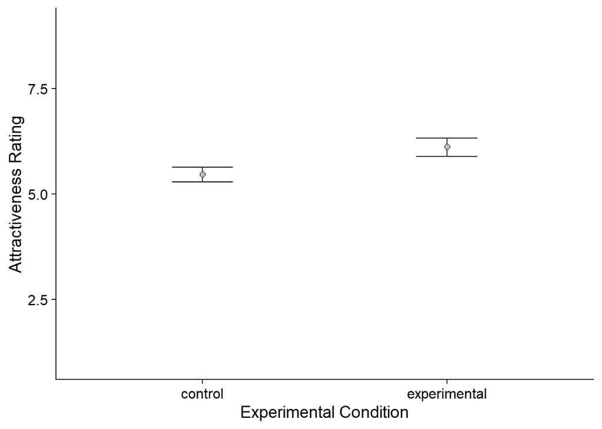

Table 1 * Descriptive statistic by Question 1*

| Question 1 | *N* | % | *M*<sub>age</sub> | *SD*<sub>age</sub> |
| --- | --- | --- | --- | --- |
| 2 | 1 | 0.81 | 23.00 | NA |
| 3 | 5 | 4.03 | 21.60 | 2.07 |
| 4 | 12 | 9.68 | 19.92 | 1.98 |
| 5 | 32 | 25.81 | 20.78 | 2.20 |
| 6 | 32 | 25.81 | 21.44 | 2.26 |
| 7 | 30 | 24.19 | 21.93 | 1.82 |
| 8 | 9 | 7.26 | 20.33 | 2.40 |
| 9 | 3 | 2.42 | 21.33 | 2.08 |

Table 2 * Descriptive statistic by Question 2*

| Question 2 | *N* | % | *M*<sub>age</sub> | *SD*<sub>age</sub> |
| --- | --- | --- | --- | --- |
| 3 | 3 | 2.42 | 20.00 | 1.73 |
| 4 | 23 | 18.55 | 21.43 | 1.80 |
| 5 | 32 | 25.81 | 20.81 | 2.58 |
| 6 | 33 | 26.61 | 21.36 | 2.16 |
| 7 | 28 | 22.58 | 21.46 | 1.97 |
| 8 | 3 | 2.42 | 19.67 | 1.53 |
| 9 | 2 | 1.61 | 21.00 | 2.83 |

Table 3 * Descriptive statistic by Question 3*

| Question 3 | *N* | % | *M*<sub>age</sub> | *SD*<sub>age</sub> |
| --- | --- | --- | --- | --- |
| 2 | 1 | 0.81 | 28.00 | NA |
| 3 | 7 | 5.65 | 20.86 | 1.77 |
| 4 | 10 | 8.06 | 21.70 | 2.11 |
| 5 | 31 | 25.00 | 20.58 | 1.93 |
| 6 | 34 | 27.42 | 21.85 | 2.26 |
| 7 | 27 | 21.77 | 20.56 | 1.91 |
| 8 | 12 | 9.68 | 21.75 | 1.86 |
| 9 | 2 | 1.61 | 19.00 | 0.00 |

Table 4 * Descriptive statistic by attractiveness mean*

| Attractiveness mean rating | *N* | % | *M*<sub>age</sub> | *SD*<sub>age</sub> |
| --- | --- | --- | --- | --- |
| 4.00 | 3 | 2.42 | 20.00 | 2.65 |
| 4.33 | 4 | 3.23 | 23.75 | 2.99 |
| 4.67 | 7 | 5.65 | 20.71 | 1.50 |
| 5.00 | 22 | 17.74 | 21.09 | 2.18 |
| 5.33 | 13 | 10.48 | 19.92 | 1.55 |
| 5.67 | 14 | 11.29 | 22.00 | 2.66 |
| 6.00 | 22 | 17.74 | 20.91 | 1.82 |
| 6.33 | 14 | 11.29 | 21.79 | 1.89 |
| 6.67 | 11 | 8.87 | 21.27 | 2.33 |
| 7.00 | 9 | 7.26 | 21.33 | 2.40 |
| 7.33 | 3 | 2.42 | 20.67 | 1.15 |
| 8.00 | 1 | 0.81 | 19.00 | NA |
| 8.33 | 1 | 0.81 | 23.00 | NA |

We investigated whether participants would give rate attractiveness of a man higher depending on the colour of the photoframe, using an independent-measures t-test. The analysis indicated that, as predicted,the mean attractiveness rating for the control condition (*M* = 5.46) would be lower than the mean attractiveness rating for the experimental condition (*M* = 6.12). This difference in mean is significant (*M*<sub>diff</sub> = -0.66, 95% CI [-0.94, -0.38], *t* (122) = -4.65, *p* = 0). This means that the participants who saw a photo of a man in a red photo frame rated him more attractive than participants who saw a photo of a man in a white frame.

# Discussion

The present study has found that when an image of a male is connected to the colour red , in the case of the study this being the photo of the man being in a red frame, participants ratings across the three questions was significantly greater than that of the participants who viewed the photo of the same man in a white photo frame. This is demonstrating that when considering perceived attractiveness, the colour red can influence participants ratings, leading to the participants rating the man as more attractive than the same man who was in a white photo frame instead of a red one.

The Elliot et al, (2010) study, was considering the effect of the colour red and white on women’s perceived attractiveness of a man’s attractiveness. When looking at the Elliot et al study it is clear that the findings from the present study and the original one show similarities. The main conclusion which was drawn from the results was that participants in the red condition rated the male higher in perceived attractiveness than the participants in the white condition (Elliot et al, 2010). Therefore, it is apparent that the same conclusion can be made when looking at the results of the current study. However, it is important to consider a crucial difference between the current study and Elliot’s study, which is that the sample size is drastically different. The sample size in the Elliot study was 21 participants whereas the participants in the present study was a total of 150, where 124 participants data was used (Elliot et al, 2010). This is important to consider as it gives greater weight to the results from the present study as, it was a replication of the Elliot study using a larger sample and obtaining very similar results. This therefore, validates the original study. Hence, the conclusion can be made that hypothesis of this study is true and that the colour red influences participants perceived attractiveness.

Another study which considered the effect colour has on perceived attractiveness was carried out by Peperkoorn, Roberts and Pollet in 2016. This study followed a very similar procedure to the original Elliot et al study whereby the sexual attractiveness of a women was rated by participants in relation to red, white and black (Perperkootn, Roberts and Pollet, 2016). This study used Dutch and American participants (Perperkootn, Roberts and Pollet, 2016).The overall results and conclusion from this study was that the results from their study fail to support the red effect, as there was no significant difference between the attractiveness ratings and the three different colours (Perperkootn, Roberts and Pollet, 2016).

Although the results from the current study are similar to the results of the original study is necessary to also consider how the results of this study will compare to other studies or replication attempts investigating the same or similar topic of the effect colour has on attractiveness.

Hesslinger, Goldbach and Carbon carried out a close replication of experiment 1 in the Elliot et al study (Hesslinger, Goldbach and Carbon, 2015). Hesslinger et al (2015), used the same photo of the man that was used in the Elliot et al study on a red or white background, and used the same three questions used in the Elliot et al study and the current study. This study found that after calculating a composite score of perceived attractiveness, that the results from the control and experimental conditions were very similar with little differences between the composite scores, meaning that the scores were not statistically significant (Hesslinger, Goldbach and Carbon). The results of this study are different to the current study as the opposite effect was found. Hesslinger et al, took the replication even further a considered the role gender may play, thus there was a reanalysis of the data after it was split by gender and again there was no significant effect of the colour condition on the participant perceived attractiveness (Hesslinger, Goldbach and Carbon)

After considering other studies results when replicating the Elliot et al study, it is possible that the colour red isn’t the only factor which may influence perceived attractiveness, this can be said as the Hesslinger et al research went further and considered apparel style as an additional factor to perceived attractiveness (Hesslinger, Goldbach and Carbon). It was found that men who were wearing more formal apparel were considered more attractive than men wearing causal apparel (Hesslinger, Goldbach and Carbon). Therefore it possible that the red effect that was reported by Elliot et al (2010) needs to be challenged by other research to test the effect of the colour red on percieved attractiveness.

In order to appropriately evaluate and criticise this topic and the current research, it is important to discuss the strengths and limitations of the current study. The current research, has a generally large sample size in comparison to the Elliot et al (2010) study. A larger sample size means that there is room for more generalisations to the wider population. Due to the current study following a close replication of the Elliot et al study it is possible that this may be a limitation due to other possible influences on attractiveness not being considered.

Based on my own analysis and considering previous research it has allowed me to reach the judgement that the colour red alone doesn’t influence perceived attractiveness but a combination of other factors, such as apparel style. It is possible to assume that the extent to which colour influences perceived attractiveness may be dependent on the individual, the population and possibly gender. As previous research has found that when women are rated on their attractiveness when they are associated with the colour red there is no significance effect which is the opposite to what Elliots et al 2010 study found when a males attractiveness was rated in relation with the colour red. It is undeniable that the colour red does influence perceived attractiveness, however it isn’t the sole influence on perceived attractiveness.

The research question of whether the colour red influences attractiveness is worth investigating further. In order to do so, it would be plausible to suggests that an area worth investigating further with regards to attractiveness and the colour red would be to consider the impact gender plays on the red effect and considering how development may play a part in it.

# References

Elliot, A. J., Niesta Kayser, D., Greitemeyer, T., Lichtenfeld, S., Gramzow, R. H., Maier, M. A., & Liu, H. (2010). Red, rank, and romance in women viewing men. Journal of Experimental Psychology: General, 139(3), 399.

Hesslinger, V. M., Goldbach, L., & Carbon, C. C. (2015). Men in red: A reexamination of the red-attractiveness effect. Psychonomic bulletin & review, 22(4), 1142-1148.

Peperkoorn, L. S., Roberts, S. C., & Pollet, T. V. (2016). Revisiting the red effect on attractiveness and sexual receptivity: No effect of the color red on human mate preferences. Evolutionary Psychology, 14(4), 1474704916673841.